### Table 2.1.1 Global and regional estimates of TB incidence, numbers (in thousands) and rates (per 100 000 population) in 2020

[output not shown]

Low and high are the 5th and 95th percentiles of the uncertainty interval (UI)

### Fig. 2.1.1 Global trends in the estimated number of incident TB cases (left) and the incidence rate (right), 2000–2020

Shaded areas represent uncertainty intervals. The horizontal dashed line shows the 2020 milestone of the End TB Strategy.

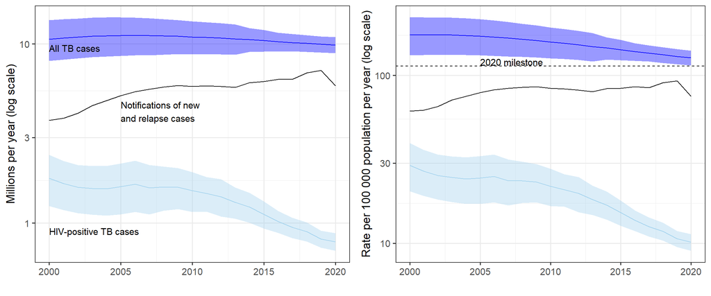

### Fig. 2.1.2 Trends in estimated TB incidence rates by WHO region, 2000–2020

Total TB incidence rates are shown in blue and incidence rates of HIV-positive TB are shown in light blue. The black solid lines show notifications of new and relapse cases for comparison with estimates of the total incidence rate. Shaded areas represent uncertainty intervals. The horizontal dashed line shows the 2020 milestone of the End TB Strategy.

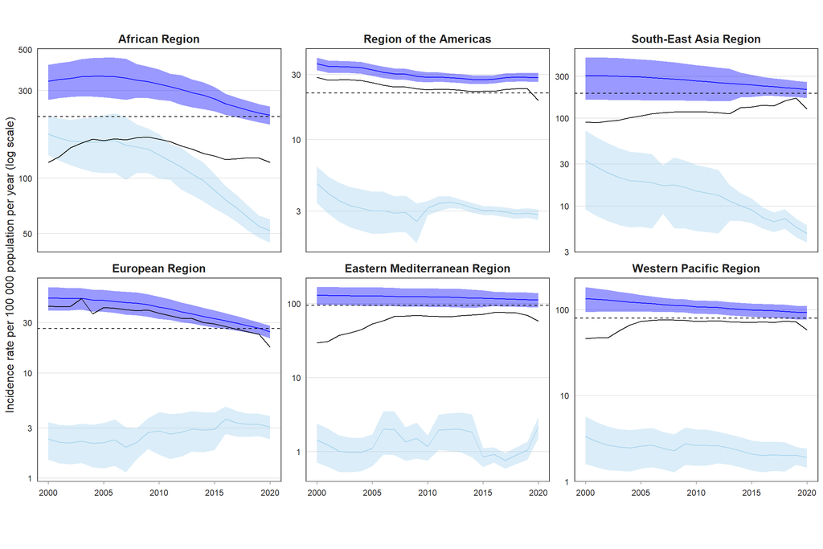

### Fig. 2.1.3a Trends in estimated TB incidence rates in the 30 high TB burden countries compared with notifications of new and relapse cases, 2000–2020

TB incidence rates are shown in blue. The black solid lines show notifications of new and relapse cases for comparison with estimates of the total incidence rate. Shaded areas represent uncertainty intervals. The horizontal dashed line shows the 2020 milestone of the End TB Strategy.

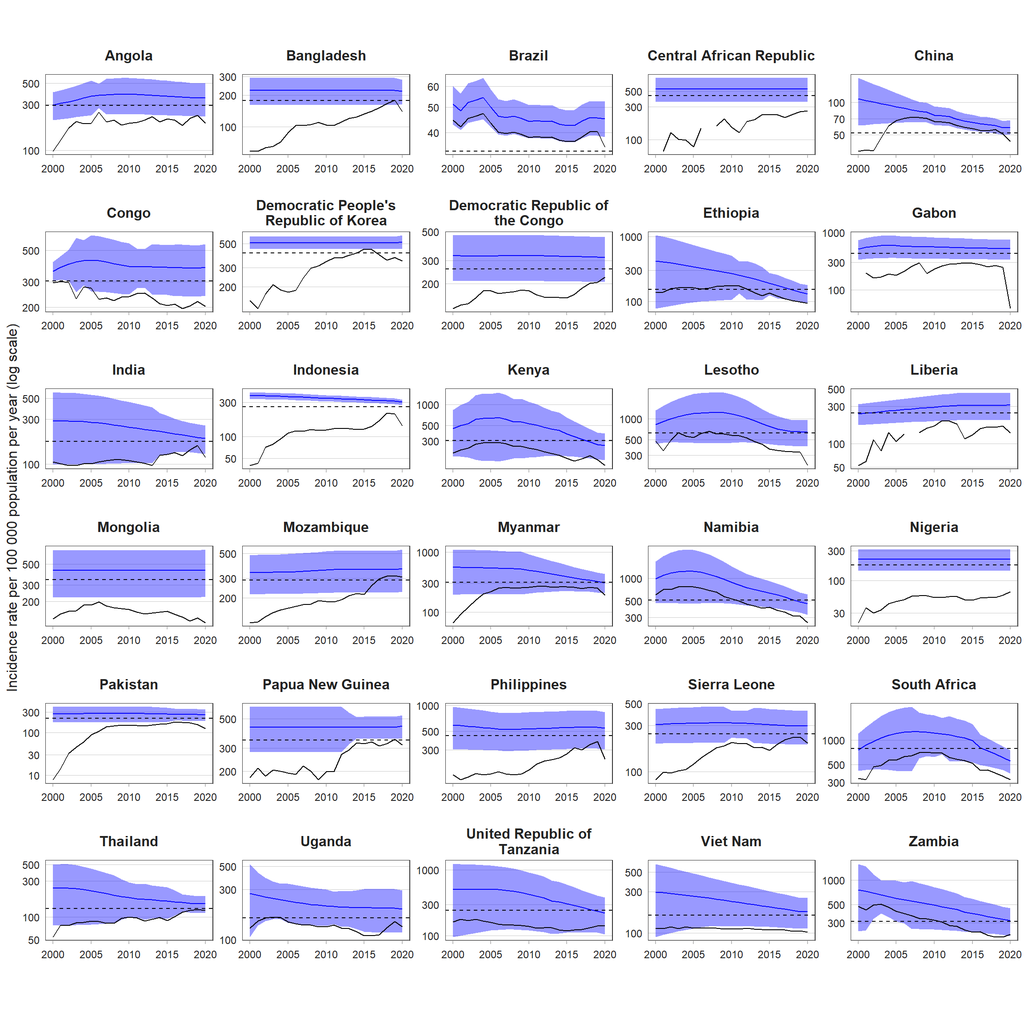

### Fig. 2.1.3b Trends in estimated TB incidence rates in the 3 global TB watchlist countries compared with notifications of new and relapse cases, 2000–2020

TB incidence rates are shown in blue. The black solid lines show notifications of new and relapse cases for comparison with estimates of the total incidence rate. Shaded areas represent uncertainty intervals. The horizontal dashed line shows the 2020 milestone of the End TB Strategy.

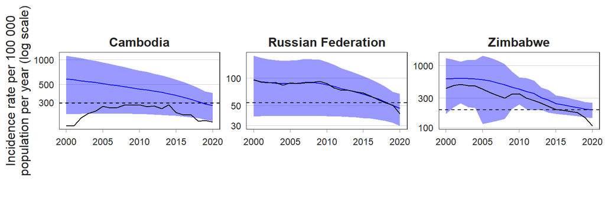

### Fig. 2.1.4 Estimated TB incidence in 2020, for countries with at least 100 000 incident cases

The eight countries that rank first to eighth in terms of numbers of cases, and that accounted for two thirds of global cases in 2020, are labelled.

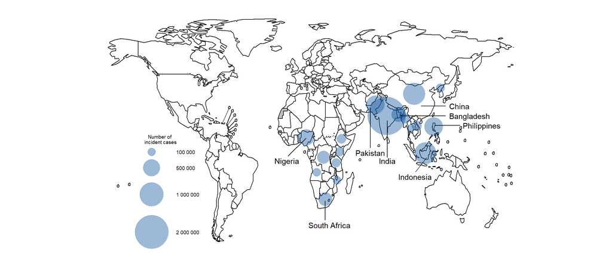

### Fig. 2.1.5 Estimated TB incidence rates, 2020

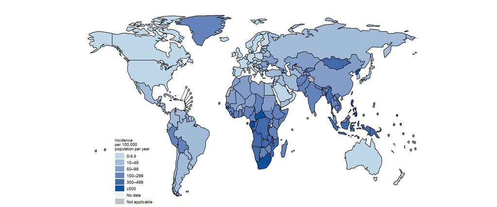

### Fig. 2.1.6 Estimated HIV prevalence in new and relapse TB cases, 2020

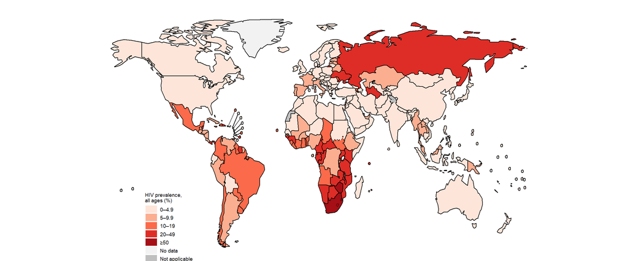

### Fig. 2.1.7a Global estimates of TB incidence (black outline) and case notifications disaggregated by age and sex (female in purple; male in green), 2020

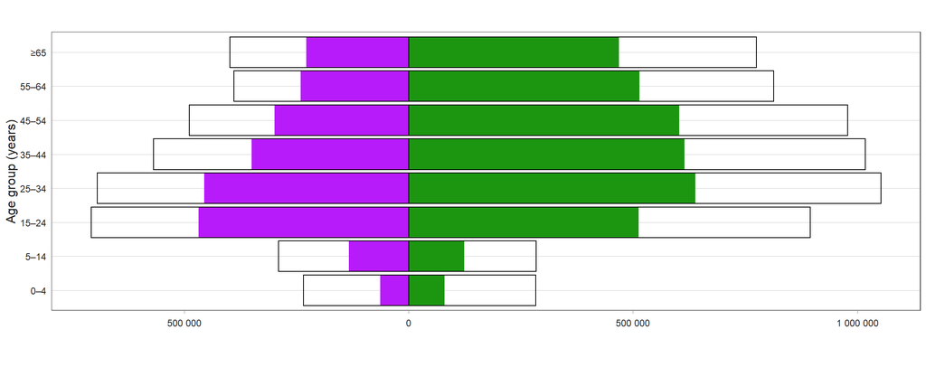

### Fig. 2.1.7b Regional estimates of TB incidence (black outline, in thousand) and case notifications (in thousand) disaggregated by age and sex (female in purple; male in green), 2020

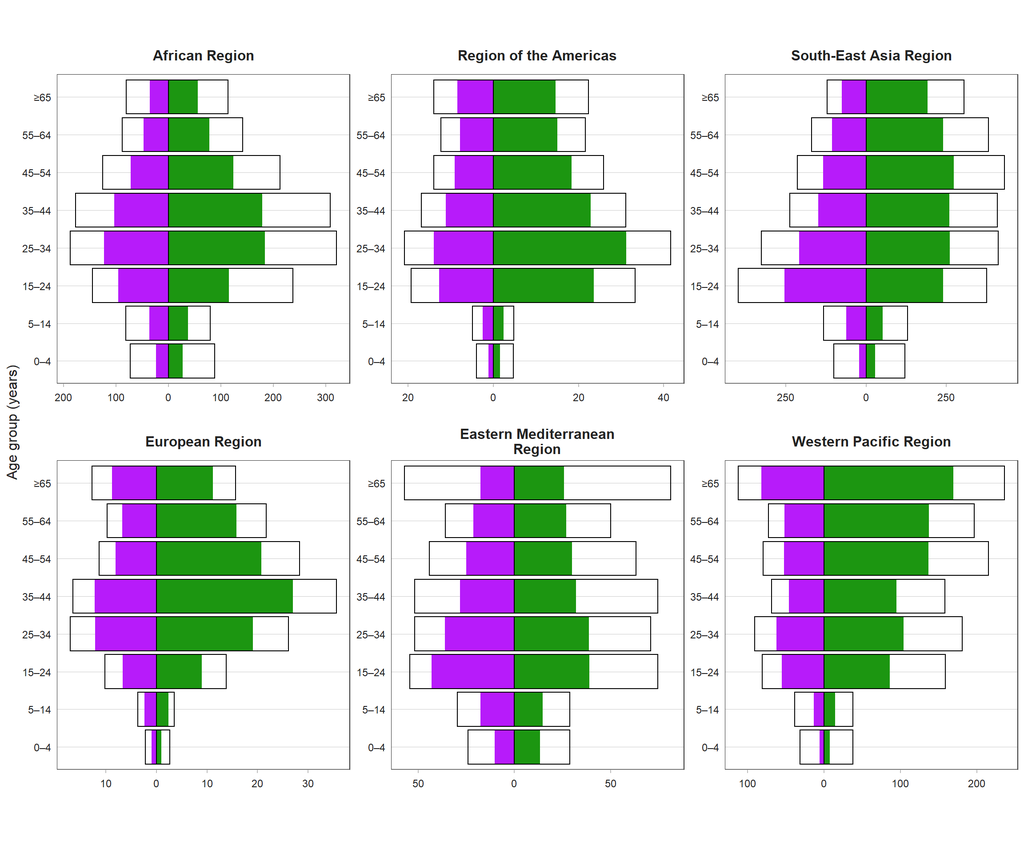

### Fig. 2.1.8a Main methods used to estimate TB incidence up to 2019

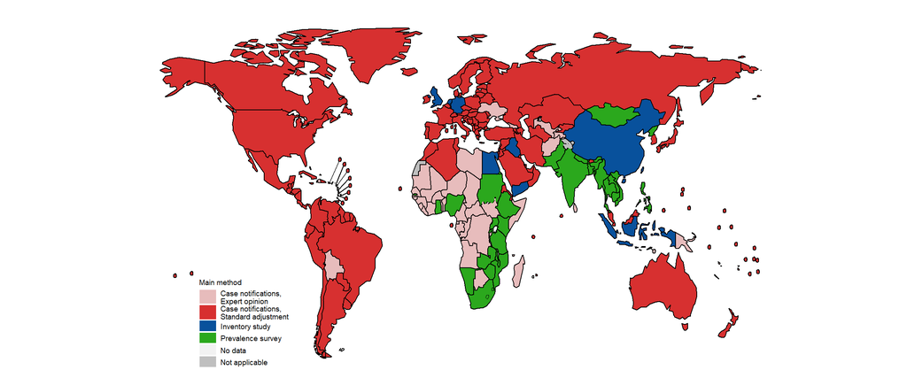

### Fig. 2.1.8b Main methods used to estimate TB incidence in 2020

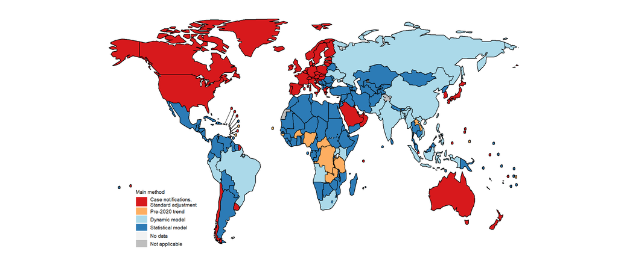